### **第二周作业**

#### **一、证明：多元正态分布的边缘分布也是正态分布**(可参考PRML 2.3.2)

$$X=\left[\begin{array}{l}
X_{a} \\
X_{b}
\end{array}\right], \quad \mu=\left[\begin{array}{l}
\mu_{a} \\
\mu_{b}
\end{array}\right], \quad
\Sigma=\left[\begin{array}{ll}
\Sigma_{aa} & \Sigma_{ab} \\
\Sigma_{ba} & \Sigma_{bb}
\end{array}\right]$$
若$X \sim N(\mu, \Sigma)$ ，证明$X_{a} \sim N\left(\mu_{a}, \Sigma_{aa}\right), X_{b} \sim N\left(\mu_{b}, \Sigma_{bb}\right)$

**证明：**

边缘概率分布为 $p\left(\boldsymbol{x}_{a}\right)=\int p\left(\boldsymbol{x}_{a}, \boldsymbol{x}_{b}\right) \mathrm{d} \boldsymbol{x}_{b}$

协方差矩阵的逆矩阵记为$\boldsymbol{\Lambda} \equiv \boldsymbol{\Sigma}^{-1}$，精度矩阵的划分为 $\mathbf{\Lambda}=\left(\begin{array}{ll}\boldsymbol{\Lambda}_{aa} & \boldsymbol{\Lambda}_{ab} \\ \boldsymbol{\Lambda}_{ba} & \boldsymbol{\Lambda}_{bb}\end{array}\right)$

$X$联合分布的指数项的二次型：
$$\begin{aligned}
&-\frac{1}{2}(\boldsymbol{x}-\boldsymbol{\mu})^{T} \boldsymbol{\Sigma}^{-1}(\boldsymbol{x}-\boldsymbol{\mu})= \\
&\quad-\frac{1}{2}\left(\boldsymbol{x}_{a}-\boldsymbol{\mu}_{a}\right)^{T} \boldsymbol{\Lambda}_{a a}\left(\boldsymbol{x}_{a}-\boldsymbol{\mu}_{a}\right)-\frac{1}{2}\left(\boldsymbol{x}_{a}-\boldsymbol{\mu}_{a}\right)^{T} \boldsymbol{\Lambda}_{a b}\left(\boldsymbol{x}_{b}-\boldsymbol{\mu}_{b}\right) \\
&\quad-\frac{1}{2}\left(\boldsymbol{x}_{b}-\boldsymbol{\mu}_{b}\right)^{T} \boldsymbol{\Lambda}_{b a}\left(\boldsymbol{x}_{a}-\boldsymbol{\mu}_{a}\right)-\frac{1}{2}\left(\boldsymbol{x}_{b}-\boldsymbol{\mu}_{b}\right)^{T} \boldsymbol{\Lambda}_{b b}\left(\boldsymbol{x}_{b}-\boldsymbol{\mu}_{b}\right)
\end{aligned}
\tag{2.70}$$

其中关于$x_b$的项有
$$-\frac{1}{2} \boldsymbol{x}_{b}^{T} \boldsymbol{\Lambda}_{b b} \boldsymbol{x}_{b}+\boldsymbol{x}_{b}^{T} \boldsymbol{m}=-\frac{1}{2}\left(\boldsymbol{x}_{b}-\boldsymbol{\Lambda}_{b b}^{-1} \boldsymbol{m}\right)^{T} \boldsymbol{\Lambda}_{b b}\left(\boldsymbol{x}_{b}-\boldsymbol{\Lambda}_{b b}^{-1} \boldsymbol{m}\right)+\frac{1}{2} \boldsymbol{m}^{T} \boldsymbol{\Lambda}_{b b}^{-1} \boldsymbol{m}
\tag{2.84}$$

其中
$$\boldsymbol{m}=\boldsymbol{\Lambda}_{b b} \boldsymbol{\mu}_{b}-\boldsymbol{\Lambda}_{b a}\left(\boldsymbol{x}_{a}-\boldsymbol{\mu}_{a}\right)
\tag{2.85}$$
整理后的上式的第二项与$x_b$无关，所以对于$x_b$积分的形式为：
$$\int \exp \left\{-\frac{1}{2}\left(\boldsymbol{x}_{b}-\boldsymbol{\Lambda}_{b b}^{-1} \boldsymbol{m}\right)^{T} \boldsymbol{\Lambda}_{b b}\left(\boldsymbol{x}_{b}-\boldsymbol{\Lambda}_{b b}^{-1} \boldsymbol{m}\right)\right\} \mathrm{d} \boldsymbol{x}_{b}
\tag{2.86}$$
该结构可以通过对$x_b$配出平方项的方法积分出来。那么唯一与$x_a$相关的项就是公式（2.84）的右侧的最后一项，其中m由公式（2.85）给出。把这一项与公式（2.70）中余下的与$x_a$相关的项结合，我们有：
$$\begin{aligned}
\frac{1}{2}\left[\boldsymbol{\Lambda}_{b b} \boldsymbol{\mu}_{b}\right.&\left.-\boldsymbol{\Lambda}_{b a}\left(\boldsymbol{x}_{a}-\boldsymbol{\mu}_{a}\right)\right]^{T} \boldsymbol{\Lambda}_{b b}^{-1}\left[\boldsymbol{\Lambda}_{b b} \boldsymbol{\mu}_{b}-\boldsymbol{\Lambda}_{b a}\left(\boldsymbol{x}_{a}-\boldsymbol{\mu}_{a}\right)\right] \\
&-\frac{1}{2} \boldsymbol{x}_{a}^{T} \boldsymbol{\Lambda}_{a a} \boldsymbol{x}_{a}+\boldsymbol{x}_{a}^{T}\left(\boldsymbol{\Lambda}_{a a} \boldsymbol{\mu}_{a}+\boldsymbol{\Lambda}_{a b} \boldsymbol{\mu}_{b}\right)+\text { 常数 } \\
=&-\frac{1}{2} \boldsymbol{x}_{a}^{T}\left(\boldsymbol{\Lambda}_{a a}-\boldsymbol{\Lambda}_{a b} \boldsymbol{\Lambda}_{b b}^{-1} \boldsymbol{\Lambda}_{b a}\right) \boldsymbol{x}_{a} \\
&+\boldsymbol{x}_{a}^{T}\left(\boldsymbol{\Lambda}_{a a}-\boldsymbol{\Lambda}_{a b} \boldsymbol{\Lambda}_{b b}^{-1} \boldsymbol{\Lambda}_{b a}\right) \boldsymbol{\mu}_{a}+\text { 常数 }
\end{aligned}
\tag{2.87}$$
注意一个高斯分布$\mathcal{N}(\boldsymbol{x} \mid \boldsymbol{\mu}, \boldsymbol{\Sigma})$的指数项可以写成：
$$-\frac{1}{2}(\boldsymbol{x}-\boldsymbol{\mu})^{T} \boldsymbol{\Sigma}^{-1}(\boldsymbol{x}-\boldsymbol{\mu})=-\frac{1}{2} \boldsymbol{x}^{T} \boldsymbol{\Sigma}^{-1} \boldsymbol{x}+\boldsymbol{x}^{T} \boldsymbol{\Sigma}^{-1} \boldsymbol{\mu}+\text { 常数 }$$

该二次型定义了高斯分布的指数项，因此如果把普通的二次型表示成上式右侧的形式，令$x$中的二阶项的系数矩阵等于协方差矩阵的逆矩阵$\Sigma^{-1}$，令$x$中的线性项的系数等于$\Sigma^{-1}\mu$，这样我们就可以得到$\mu$。

所以有$p(x_a)$的协方差矩阵和均值为：
$$\boldsymbol{\Sigma}_{a}=\left(\boldsymbol{\Lambda}_{a a}-\boldsymbol{\Lambda}_{a b} \boldsymbol{\Lambda}_{b b}^{-1} \boldsymbol{\Lambda}_{b a}\right)^{-1}$$
$$\boldsymbol{\Sigma}_{a}\left(\boldsymbol{\Lambda}_{a a}-\boldsymbol{\Lambda}_{a b} \boldsymbol{\Lambda}_{b b}^{-1} \boldsymbol{\Lambda}_{b a}\right) \boldsymbol{\mu}_{a}=\boldsymbol{\mu}_{a}$$

注意精度矩阵和协方差矩阵的分块矩阵有如下关系：
$$\left(\begin{array}{ll}
\boldsymbol{\Lambda}_{a a} & \boldsymbol{\Lambda}_{a b} \\
\boldsymbol{\Lambda}_{b a} & \boldsymbol{\Lambda}_{b b}
\end{array}\right)^{-1}=\left(\begin{array}{ll}
\boldsymbol{\Sigma}_{a a} & \boldsymbol{\Sigma}_{a b} \\
\boldsymbol{\Sigma}_{b a} & \boldsymbol{\Sigma}_{b b}
\end{array}\right)$$
由于分块矩阵满足
$$\left(\begin{array}{ll}
\boldsymbol{A} & \boldsymbol{B} \\
\boldsymbol{C} & \boldsymbol{D}
\end{array}\right)^{-1}=\left(\begin{array}{cc}
\boldsymbol{M} & -\boldsymbol{M} \boldsymbol{B} \boldsymbol{D}^{-1} \\
-\boldsymbol{D}^{-1} \boldsymbol{C M} & \boldsymbol{D}^{-1}+\boldsymbol{D}^{-1} \boldsymbol{C M B D}^{-1}
\end{array}\right)$$
其中$\boldsymbol{M}=\left(\boldsymbol{A}-\boldsymbol{B} \boldsymbol{D}^{-1} \boldsymbol{C}\right)^{-1}$。

所以有
$$\left(\boldsymbol{\Lambda}_{a a}-\boldsymbol{\Lambda}_{a b} \boldsymbol{\Lambda}_{b b}^{-1} \boldsymbol{\Lambda}_{b a}\right)^{-1}=\boldsymbol{\Sigma}_{a a}$$
故边缘概率分布为$p\left(\boldsymbol{x}_{a}\right)=\mathcal{N}\left(\boldsymbol{x}_{a} \mid \boldsymbol{\mu}_{a}, \mathbf{\Sigma}_{a a}\right)$。

#### **二、证明：实对称矩阵一定正交相似于对角矩阵**（Slide P16）

**证明：**  
使用数学归纳法证明：

n=1时显然成立。  
假设任意一个$n-1$级实对称矩阵都能正交相似于对角矩阵，来看$n$级实对称矩阵A。  
取 A的一个特征值$\lambda_1$和对应的单位特征向量$\eta_{1}$，$\eta_{1}$可扩充为$R^{n}$的一个基，然后经过正交和标准化后可以得到一组标准正交基$T=\left\{\eta_{1}, \eta_{2} \ldots \eta_{n}\right\}$。

令$T_1=(\eta_1，\eta_2，…，\eta_n)$, 则$T_1$是n级正交矩阵,

$$T_1^{-1}AT_1=T_1^{-1}(A\eta_1，A\eta_2，…，A\eta_n)=(T_1^{-1}\lambda_1\eta_1，T_1^{-1}A\eta_2，…，T_1^{-1}A\eta_n)$$

因为$T_{1}^{-1} T_{1}=1$，所以$T_{1}^{-1}\left(\eta_{1} \cdot \eta_{2}, \cdots, \eta_{n}\right)=\left(\varepsilon_{1}, \epsilon_{2}, \cdots, \varepsilon_{n}\right)$。于是有$T_{1}^{-1} \eta_{1}=\varepsilon_{1}$。$T_{1}^{-1} A T_{1}$ 的第 1 列是 $\lambda_{1} \in_{1}$. 因此可以设
$$T_{1}^{-1} A T_{1}=\left(\begin{array}{cc}\lambda_{1} & a \\ 0 & B\end{array}\right)$$
由于 $T_{1}$ 是正交矩阵, $A$ 是实对称矩阵, 因此 $T_{1}^{-1} A T_{1}$ 戊是实对称矩阵. 从而得, $a=0$, 井且 $B$是 $n-1$级实对称矩阵。 根据归纳假设,有 $n-1$ 级正交矩阵$T_2$，使得$T_2^{-1}BT_2=diag \lbrace \lambda_2，…，\lambda_n \rbrace$。

令 $T=T_{1}\left(\begin{array}{cc}1 & 0 \\ 0 & T_{2}\end{array}\right)$, 则 $T$ 为正交阵，

$$\begin{aligned} T^{-1} A T &=\left(\begin{array}{cc}1 & 0 \\ 0 & T_{2}\end{array}\right)^{T} T_{1}^{-1} A T_{1}\left(\begin{array}{cc}1 & 0 \\ 0 & T_{2}\end{array}\right) \\ &=\left(\begin{array}{cc}1 & 0 \\ 0 & T_{2}\end{array}\right)^{T}\left(\begin{array}{cc}\lambda_{1} & 0 \\ 0 & B\end{array}\right)\left(\begin{array}{cc}1 & 0 \\ 0 & T_{2}\end{array}\right) \\ &=\left(\begin{array}{cc}\lambda_{1} & 0 \\ 0 & T_{2}^{-1} B T_{2}\end{array}\right) \\ &=\operatorname{diag}\left\{\lambda_{1}, \lambda_{2}, \ldots, \lambda_{n}\right\} \end{aligned}$$

#### **三、**

3.1 将$8\times8$维的数据文件读入(见adj_8times8.csv)，记为A矩阵。

```r
A = as.matrix(read.csv("adj_8times8.csv",header=F))
A
```

```
##      V1 V2 V3 V4 V5 V6 V7 V8
## [1,]  0  1  1  1  0  0  0  1
## [2,]  1  0  1  0  0  0  0  0
## [3,]  1  1  0  0  0  0  0  1
## [4,]  1  0  0  0  1  1  0  0
## [5,]  0  0  0  1  0  1  1  0
## [6,]  0  0  0  1  1  0  1  0
## [7,]  0  0  0  0  1  1  0  0
## [8,]  1  0  1  0  0  0  0  0
```

3.2 对矩阵A求特征根和特征向量，记最大的特征根为$\lambda_{1}$，对应的特征向量记为$\xi_{1}$，第二大特征根及特征向量为$\lambda_{2},\xi_{2}$，依此类推。

```r
A.e = eigen(A)
lambda = A.e$values
xi = A.e$vectors
lambda
```

```
## [1]   2.872276e+00   2.370326e+00   2.031849e-01  1.262113e-307  -1.000000e+00
## [6]  -1.000000e+00  -1.445787e+00  -2.000000e+00
```

```r
xi
```

```
##            [,1]       [,2]        [,3]          [,4]          [,5]
## [1,] -0.4760174  0.3247597 -0.25594915  0.000000e+00  0.000000e+00
## [2,] -0.2949247  0.3024907  0.15722247 -7.071068e-01  1.020146e-16
## [3,] -0.3710879  0.3922419  0.28789438 -1.387779e-16  1.172716e-16
## [4,] -0.4063162 -0.2274370 -0.65434431  2.775558e-17  3.814243e-17
## [5,] -0.3455174 -0.4319297  0.06149814  1.665335e-16  7.071068e-01
## [6,] -0.3455174 -0.4319297  0.06149814 -1.110223e-16 -7.071068e-01
## [7,] -0.2405879 -0.3644475  0.60534167  2.775558e-17  2.482534e-17
## [8,] -0.2949247  0.3024907  0.15722247  7.071068e-01 -2.574287e-16
##               [,6]        [,7]          [,8]
## [1,]  5.345225e-01  0.09498408 -5.547002e-01
## [2,]  2.775558e-16 -0.46891021  2.773501e-01
## [3,] -5.345225e-01  0.58296022 -3.330669e-16
## [4,] -4.579670e-16  0.21753344  5.547002e-01
## [5,] -2.672612e-01 -0.20474555 -2.773501e-01
## [6,] -2.672612e-01 -0.20474555 -2.773501e-01
## [7,]  5.345225e-01  0.28323058  2.773501e-01
## [8,]  1.665335e-16 -0.46891021  2.773501e-01
```

```r
B <- cbind(xi[,2]/xi[1],xi[,3]/xi[,1])
B
```

```
##            [,1]       [,2]
## [1,] -0.6822433  0.5376886
## [2,] -0.6354614 -0.5330935
## [3,] -0.8240074 -0.7758118
## [4,]  0.4777913  1.6104313
## [5,]  0.9073822 -0.1779885
## [6,]  0.9073822 -0.1779885
## [7,]  0.7656180 -2.5160937
## [8,] -0.6354614 -0.5330935
```

3.4 可以将矩阵$B$看作8个点的坐标，使用k-means方法进行聚类，并分析聚类的效果。

```r
c2 = kmeans(B,2)
c3 = kmeans(B,3)
c4 = kmeans(B,4)

df_b = data.frame(B,c2$cluster,c3$cluster,c4$cluster)
df_b[,3:5]=lapply(df_b[,3:5],factor)

library(ggplot2)
library(ggrepel)
library(ggpubr)
p1 = ggplot(df_b,aes(x=X1,y=X2,colour=c2.cluster,label=rownames(df_b)))+
  geom_point()+geom_label_repel(aes(x=X1,y=X2,label=rownames(df_b)),data=df_b)+theme_bw()
p2 = ggplot(df_b,aes(x=X1,y=X2,colour=c3.cluster,label=rownames(df_b)))+
  geom_point()+geom_label_repel(aes(x=X1,y=X2,label=rownames(df_b)),data=df_b)+theme_bw()
p3 = ggplot(df_b,aes(x=X1,y=X2,colour=c4.cluster,label=rownames(df_b)))+
  geom_point()+geom_label_repel(aes(x=X1,y=X2,label=rownames(df_b)),data=df_b)+theme_bw()
```

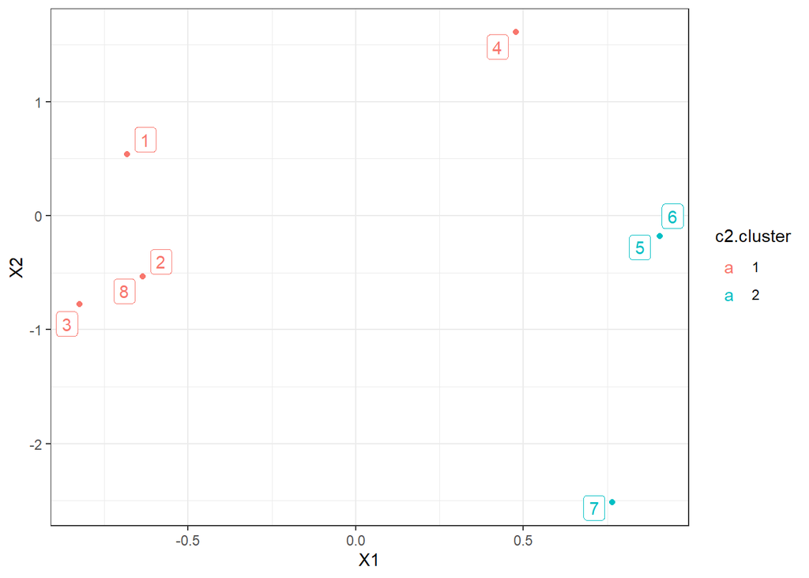

```r
p1
```

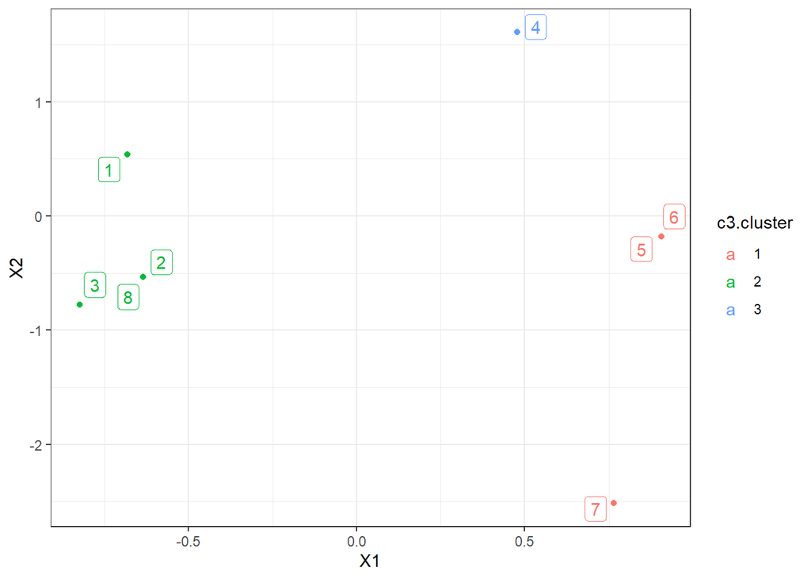

```r
p2
```

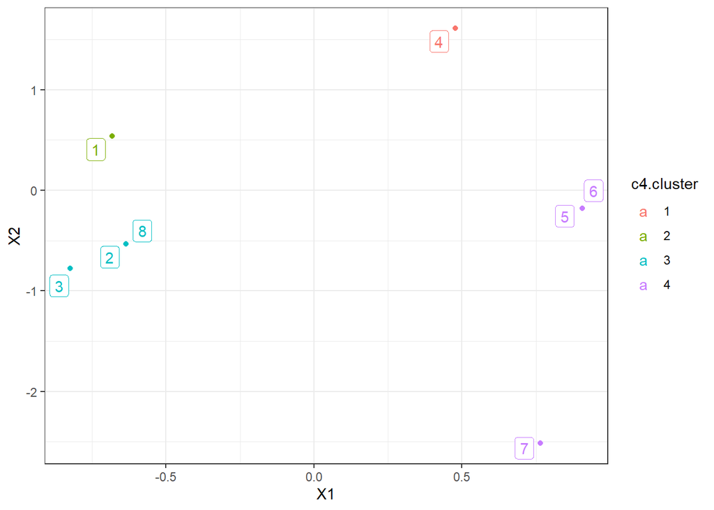

```r
p3
```

```r
library(igraph)
```

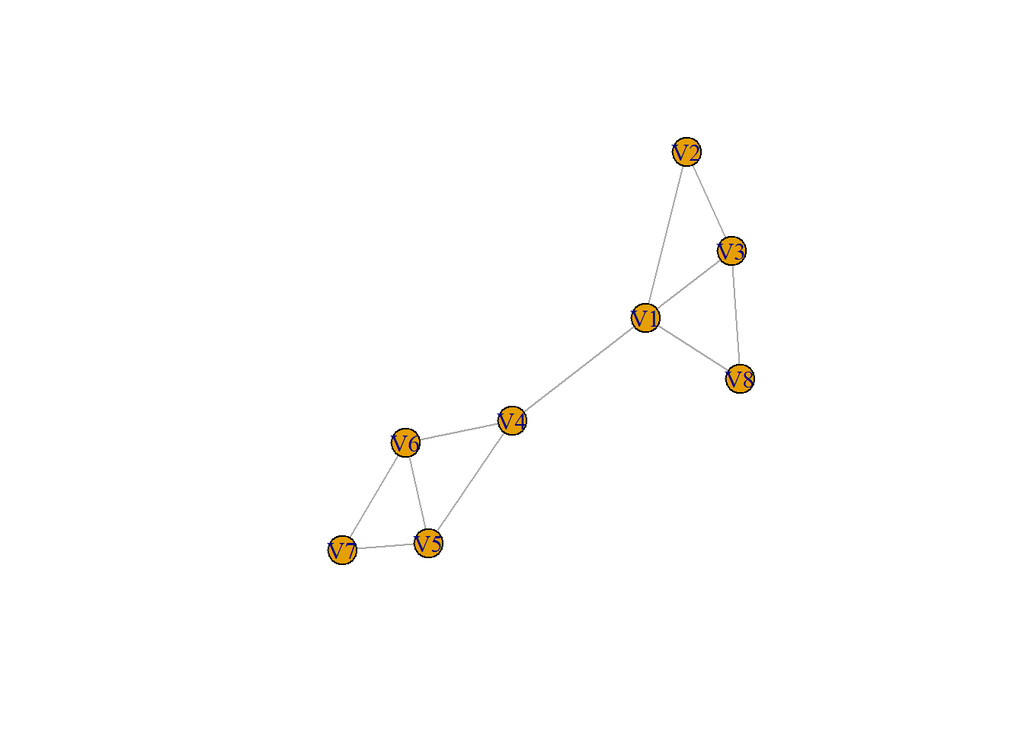

```r
g <- graph.adjacency(A,mode = "undirected")
plot(g)
```

Kmeans结果具有随机性。原始矩阵A是一个网络邻接矩阵，网络共有8个节点，如果点i和点j之间有连接的边，那么$A_{ij}$=1，否则为0。从网络结构来看，分为两类合适，1，2，3，8和4，5，6，7都是类内联通。

#### **四、**

4.1 给出矩阵A和向量b，计算回归方程Ax=b中的x（参见cs229-linalg.pdf第27页）。

方程的解为$x=\left(A^{T} A\right)^{-1} A^{T} b$。

```r
df=read.csv("LeastSq.csv",header=T)
A=as.matrix(df[,1:2])
b=df[,3]
x = solve(t(A) %*% A) %*% t(A) %*% b
x
```

```
##           [,1]
## A1  0.32881008
## A2 -0.05477116
```

4.2 计算矩阵$X^TA^TAX$对$X$的一阶导数。  
一阶导：$\frac{\partial X^TA^TAX}{\partial X}=2A^TAX$

```r
d1=2*t(A)%*%A %*% x
#或者使用crossprod()函数，返回矩阵内积。d1=2*crossprod(A) %*% x
d1
```

```
##      [,1]
## A1 733.48
## A2 502.32
```

4.3 计算矩阵$X^TA^TAX$对$X$的二阶导数。  
二阶导：$\frac{\partial^2 X^TA^TAX}{\partial X^2}=2A^TA$

```r
d2=2*t(A)%*%A
d2
```

```
##         A1      A2
## A1 2518.18 1725.78
## A2 1725.78 1189.20
```